# class18_genome

Jocelyn Olvera

12/1/2021

```r
library(ggplot2)
library(dplyr)
expr <- read.table("../class18_genome/rs8067378_ENSG00000172057.6.txt")
head(expr)
```

|  | sample | geno | exp |
| --- | --- | --- | --- |
| 1 | HG00367 | A/G | 28.96038 |
| 2 | NA20768 | A/G | 20.24449 |
| 3 | HG00361 | A/A | 31.32628 |
| 4 | HG00135 | A/A | 34.11169 |
| 5 | NA18870 | G/G | 18.25141 |
| 6 | NA11993 | A/A | 32.89721 |

```r
nrow(expr)
```

```
## [1] 462
```

```r
table(expr$geno)
```

```
##
## A/A A/G G/G
## 108 233 121
```

```r
summary(expr)
```

```
##     sample              geno                exp
##  Length:462         Length:462         Min.   : 6.675
##  Class :character   Class :character   1st Qu.:20.004
##  Mode  :character   Mode  :character   Median :25.116
##                                        Mean   :25.640
##                                        3rd Qu.:30.779
##                                        Max.   :51.518
```

## **Q13:** Read this file into R and determine the sample size for each genotype and their corresponding median expression levels for each of these genotypes. Hint: The read.table(), summary() and boxplot() functions will likely be useful here. There is an example R script online to be used ONLY if you are struggling in vein. Note that you can find the medium value from saving the output of the boxplot() function to an R object and examining this object. There is also the medium() and summary() function that you can use to check your understanding.

### **Response:**

### A/A median = 31.24847

### A/G median = 25.06486

### G/G median = 20.07363

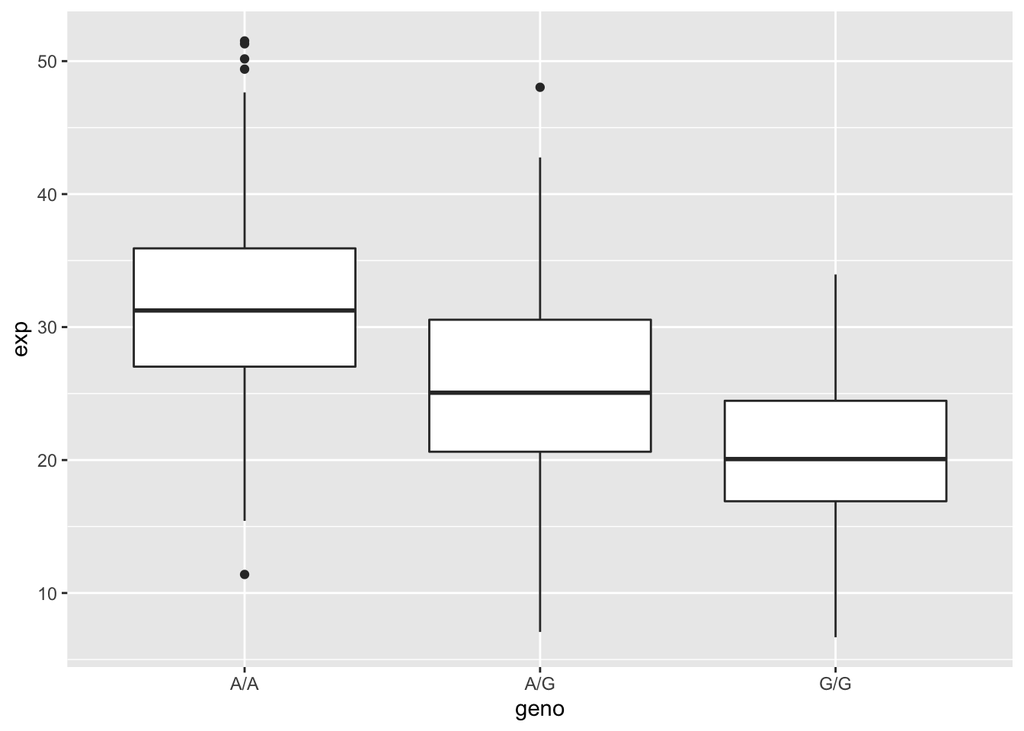

```r
ggplot(expr,
       aes(x = geno,
           y = exp)) +
  geom_boxplot()
```

```r
expr %>%
 group_by(geno) %>%
  summarise(Min = min(exp),
            Max = max(exp),
            Median = median(exp))
```

| geno | Min | Max | Median |
| --- | --- | --- | --- |
| A/A | 11.39643 | 51.51787 | 31.24847 |
| A/G | 7.07505 | 48.03410 | 25.06486 |
| G/G | 6.67482 | 33.95602 | 20.07363 |

## **Q14:** Generate a boxplot with a box per genotype, what could you infer from the relative expression value between A/A and G/G displayed in this plot? Does the SNP effect the expression of ORMDL3? Hint: An example boxplot is provided overleaf – yours does not need to be as polished as this one.

### **Response:** A/A is more highly expressed than G/G in this gene. However, the presence of G/G is associated with a decreased expression of this gene. therefore, the SNP appears to effect the expression of the ORMDL3 gene and is inferred by the presence of G/G.

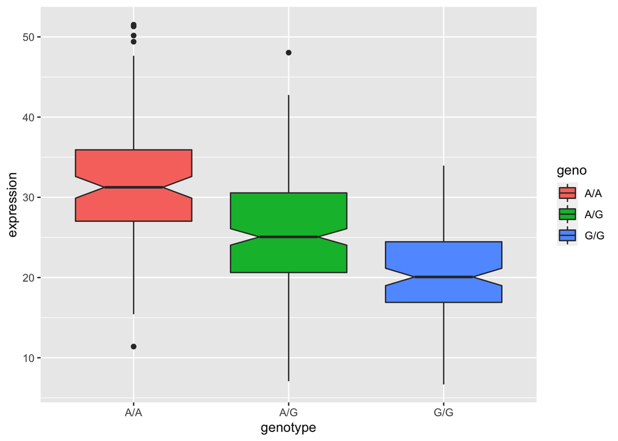

```r
bp <- ggplot(expr) + aes(geno, exp, fill=geno) +
  labs(y = "expression", x = "genotype") +
  geom_boxplot(notch = TRUE)
bp
```

## Questions #5 and 6

#### Data downloaded from: https://uswest.ensembl.org/Homo_sapiens/Variation/Sample?db=core;r=17:39903525-39926526;v=rs8067378;vdb=variation;vf=105535077#373531_tablePanel

## Section1: Proportion of G/G in a population

```r
mxl <- read.csv("../class18_genome/373531-SampleGenotypes-Homo_sapiens_Variation_Sample_rs8067378.csv")
head(mxl)
```

|  | Sample..Male.Female.Unknown. | Genotype..forward.strand. | Population.s. | Father | Mother |
| --- | --- | --- | --- | --- | --- |
| 1 | NA19648 (F) | A\|A | ALL, AMR, MXL | - | - |
| 2 | NA19649 (M) | G\|G | ALL, AMR, MXL | - | - |
| 3 | NA19651 (F) | A\|A | ALL, AMR, MXL | - | - |
| 4 | NA19652 (M) | G\|G | ALL, AMR, MXL | - | - |
| 5 | NA19654 (F) | G\|G | ALL, AMR, MXL | - | - |
| 6 | NA19655 (M) | A\|G | ALL, AMR, MXL | - | - |

```r
table(mxl$Genotype..forward.strand.)
```

```
##
## A|A A|G G|A G|G
##  22  21  12   9
```

# Total number of visuals in the dataset. Percentage of homozygous.

```r
table(mxl$Genotype..forward.strand.) / nrow(mxl) *100
```

```
##
##     A|A     A|G     G|A     G|G
## 34.3750 32.8125 18.7500 14.0625
```

```r
gbr <- read.csv("../class18_genome/373522-SampleGenotypes-Homo_sapiens_Variation_Sample_rs8067378.csv")
```

## Find proportion of GIG

```r
round(table(gbr$Genotype..forward.strand.) / nrow(gbr) *100, 2)
```

```
##
##   A|A   A|G   G|A   G|G
## 25.27 18.68 26.37 29.67
```

## This variant that is associated with childhood asthama is more frequent in the GBR population thatn the MKL population.

##Lets now dig into this further.